# BT Question P1-T2-20-20-3: Regression diagnostic plots

David Harper

2020-09-24

## BT Question 20.20.3

20.20.3. Patrick generated a simple regression line for a sample of 50 pairwise observations. After generating the regression model, he ran R’s built-in plot(model) function which produces a standard set of regression diagnostics. These four plots are displayed below.

```r
library(tidyverse)
library(broom)
library(gt)
library(ggrepel)

intercept <- 4
intercept_sig <- 1

x1_mu <- 5
x1_sig <- 1
x1_beta <- 0.3

noise_mu <- 0
noise_sig <- 5 # low value gets low p-value b/c low noise

size <- 50
set.seed(25)

rho_noise_x1 <- 0.7

x1_start = 0
x1_end = 5
x1_step = (x1_end - x1_start)/size

results <- tibble(
  x0_sn = rnorm(size),
  x1_sn = rnorm(size),
  x2_sn = rnorm(size), # needed to retain to preserve simulation results!
  e = rnorm(size),
  #
  x0 = intercept + x0_sn * intercept_sig,
  x1 = seq(x1_start, x1_end - x1_step, by = x1_step),
  e_sigma = rpois(size,2),
  x1_b = rep(x1_beta, size),
)

results1 <- results %>% mutate(
  y = x0 + (x1_b * x1) + (e * e_sigma)
)

model_1 <- lm(y ~ x1, data = results1)
summary(model_1)
```

```
##
## Call:
## lm(formula = y ~ x1, data = results1)
##
## Residuals:
##     Min      1Q  Median      3Q     Max
## -8.2138 -1.7154 -0.6175  0.8984 11.1858
##
## Coefficients:
##             Estimate Std. Error t value Pr(>|t|)
## (Intercept)   3.9116     0.9257   4.225 0.000106 ***
## x1            0.4636     0.3256   1.424 0.160933
## ---
## Signif. codes:  0 '***' 0.001 '**' 0.01 '*' 0.05 '.' 0.1 ' ' 1
##
## Residual standard error: 3.322 on 48 degrees of freedom
## Multiple R-squared:  0.04053,    Adjusted R-squared:  0.02054
## F-statistic: 2.028 on 1 and 48 DF,  p-value: 0.1609
```

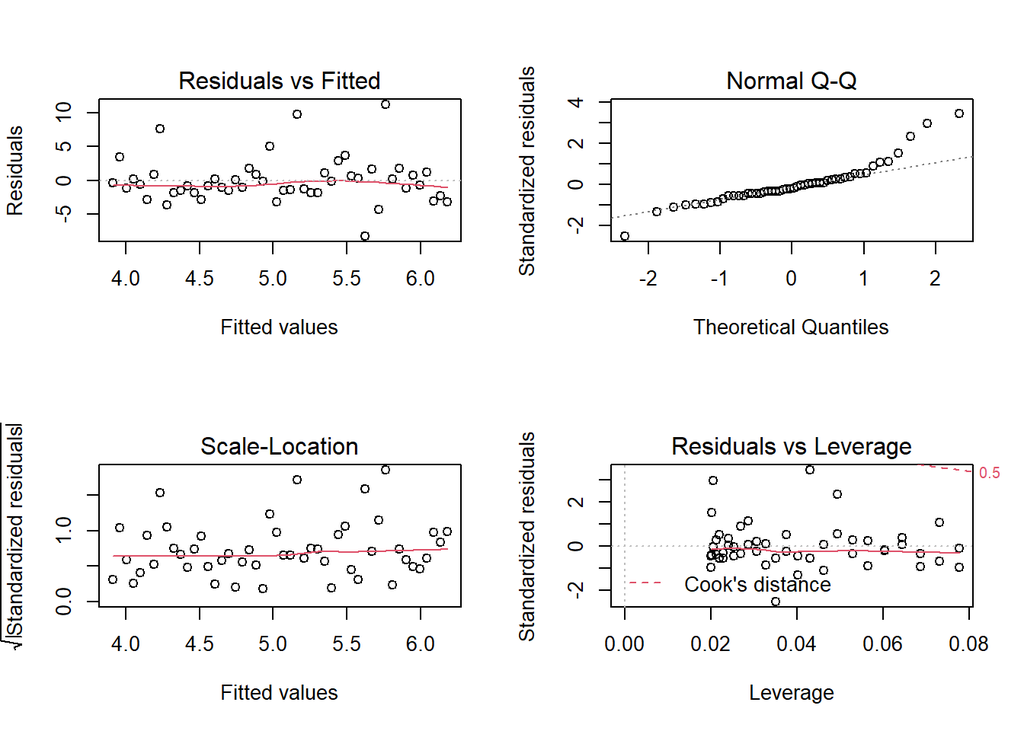

```r
# model_tidy_1 <- tidy(model_1)
# model_tidy_1[2,1] <- "Factor"

# plot(model_1)
# autoplot(model_1) # +
# geom_text(vjust=-1, label=rownames(results1))

# mean(results1$y) # price
# mean(results1$x0) # intercept
# mean(results1$x1) # sqfeet

par(mfrow = c(2,2))
plot(model_1, id.n = 0)
```

```r
# id.n: number of points to be labelled in each plot, starting with the most extreme.

model_1
```

```
##
## Call:
## lm(formula = y ~ x1, data = results1)
##
## Coefficients:
## (Intercept)           x1
##      3.9116       0.4636
```

## What do the plot() diagnostics tell us?

### Residuals vs Fitted

This plots residuals against the fitted values. We would like to see the residuals randomly scattered across the zero (which these are). The scatter pattern is relatively even suggesting homoskedasticity; i.e., we do not see a pattern that suggests heteroskedasticity. There are not many outliers. This is pretty good-looking residuals vs fitted plot suggestive of a decent linear regression.

### Normal Q-Q

If the distribution is normal, the plot will approximate along the straight line. But notice how this plot contains an obvious heavy-tail on the right side.

### Scale-location

This plot is similiar to the Residuals vs Fitted plot, but the residuals are standardized. It is also used to evaluate heteroskedasticity. But, again, we do not perceive strong evidence of a non-constant variance.